# Advanced Topics

December 15

## Miscellaneous stuff

## `assign`, `eval`, and `parse`

`assign` allows you to assign a value to a character string.

```r
assign("x",1)
x
```

```
## [1] 1
```

```r
x<--3
x
```

```
## [1] -3
```

`eval` evaluates an expression. Use `parse` with `eval` to evaluate a character string.

```r
x<-1
eval(x)
```

```
## [1] 1
```

```r
eval("x")
```

```
## [1] "x"
```

```r
eval(parse(text="x"))
```

```
## [1] 1
```

## Reading data off the internet

```r
library(XML)
nflStandings<-"http://sports.yahoo.com/nfl/standings/"
nflTables <- readHTMLTable(nflStandings)

class(nflTables)
```

```
## [1] "list"
```

```r
length(nflTables)
```

```
## [1] 9
```

```r
sapply(nflTables,class)
```

```
##         NULL         East        North        South         West
## "data.frame" "data.frame" "data.frame" "data.frame" "data.frame"
##         East        North        South         West
## "data.frame" "data.frame" "data.frame" "data.frame"
```

```r
head(lapply(nflTables,dim))
```

```
## $`NULL`
## [1] 1 3
##
## $East
## [1]  4 14
##
## $North
## [1]  4 14
##
## $South
## [1]  4 14
##
## $West
## [1]  4 14
##
## $East
## [1]  4 14
```

It looks like the first one is different, let's check.

```r
str(nflTables[[1]])
```

```
## 'data.frame':    1 obs. of  3 variables:
##  $ V1: Factor w/ 1 level "": 1
##  $ V2: Factor w/ 1 level "#UH #UHSearchWeb { font-size:13px !important; border-radius:3px!important;}#UHSearchWeb, #UHSearchProperty{ height: 30px; min-w"| __truncated__: 1
##  $ V3: Factor w/ 1 level "": 1
```

```r
str(nflTables[[2]])
```

```
## 'data.frame':    4 obs. of  14 variables:
##  $ Team   : Factor w/ 4 levels "Buffalo","Miami",..: 3 4 1 2
##  $ W      : Factor w/ 4 levels "10","5","6","8": 1 4 3 2
##  $ L      : Factor w/ 3 levels "2","5","7": 1 2 3 3
##  $ T      : Factor w/ 1 level "0": 1 1 1 1
##  $ Pct    : Factor w/ 4 levels ".417",".462",..: 4 3 2 1
##  $ PF     : Factor w/ 4 levels "240","316","325",..: 4 3 2 1
##  $ PA     : Factor w/ 4 levels "247","256","300",..: 1 2 4 3
##  $ Net Pts: Factor w/ 4 levels "-60","128","15",..: 2 4 3 1
##  $ Home   : Factor w/ 4 levels "2-3-0","3-3-0",..: 4 3 2 1
##  $ Away   : Factor w/ 3 levels "3-3-0","3-4-0",..: 3 1 2 2
##  $ Div    : Factor w/ 4 levels "0-5-0","2-2-0",..: 4 2 3 1
##  $ Conf   : Factor w/ 4 levels "3-6-0","6-4-0",..: 4 2 3 1
##  $ Last 5 : Factor w/ 2 levels "2-3-0","3-2-0": 2 2 1 1
##  $ Streak : Factor w/ 4 levels "L-1","L-2","W-1",..: 2 4 1 3
```

Look at the first one with data.

```r
nflTables[[2]][,1:7]
```

```
##          Team  W L T  Pct  PF  PA
## 1 New England 10 2 0 .833 375 247
## 2     NY Jets  8 5 0 .615 325 256
## 3     Buffalo  6 7 0 .462 316 301
## 4       Miami  5 7 0 .417 240 300
```

Lets add the conference and division names to the list and turn it into a data frame.

```r
division<-names(nflTables)[2:9]
conference<-c(rep("AFC",4),rep("NFC",5))

nflTables<-lapply(2:9,function(i)
  cbind(conference[i],division[i],nflTables[[i]][,1:7]))

length(nflTables)
```

```
## [1] 8
```

```r
nflTables[[1]]
```

```
##   conference[i] division[i]        Team  W L T  Pct  PF  PA
## 1           AFC       North New England 10 2 0 .833 375 247
## 2           AFC       North     NY Jets  8 5 0 .615 325 256
## 3           AFC       North     Buffalo  6 7 0 .462 316 301
## 4           AFC       North       Miami  5 7 0 .417 240 300
```

Use `do.call` to bind an unknown number of data frames.

```r
nflStandings<-do.call(rbind,nflTables)
names(nflStandings)[1:2]<-c("Conference","Division")
dim(nflStandings)
```

```
## [1] 32  9
```

```r
head(nflStandings)
```

```
##   Conference Division        Team  W L T  Pct  PF  PA
## 1        AFC    North New England 10 2 0 .833 375 247
## 2        AFC    North     NY Jets  8 5 0 .615 325 256
## 3        AFC    North     Buffalo  6 7 0 .462 316 301
## 4        AFC    North       Miami  5 7 0 .417 240 300
## 5        AFC    South  Cincinnati 10 3 0 .769 354 229
## 6        AFC    South  Pittsburgh  8 5 0 .615 344 260
```

## Colors

R has 657 different colors. Additional information is [here.](http://research.stowers-institute.org/efg/R/Color/Chart/)

```r
palette()
```

```
## [1] "black"   "red"     "green3"  "blue"    "cyan"    "magenta" "yellow"
## [8] "gray"
```

```r
head(colors())
```

```
## [1] "white"         "aliceblue"     "antiquewhite"  "antiquewhite1"
## [5] "antiquewhite2" "antiquewhite3"
```

## Ten Random Colors

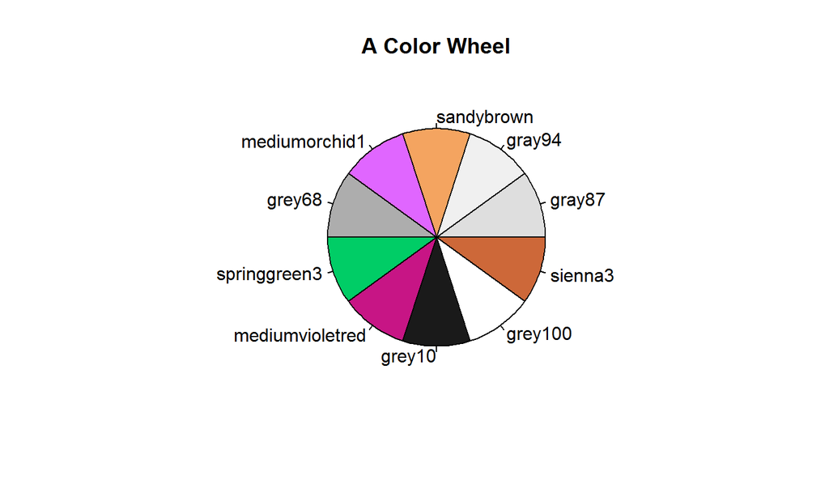

```r
set.seed(6345789)
numColors<-10
n1<-sample(1:length(colors()),replace=FALSE,
           size=numColors)
pie(rep(1,numColors),col=colors()[n1],
    labels=colors()[n1])
title(main="A Color Wheel")
```

## The default palette

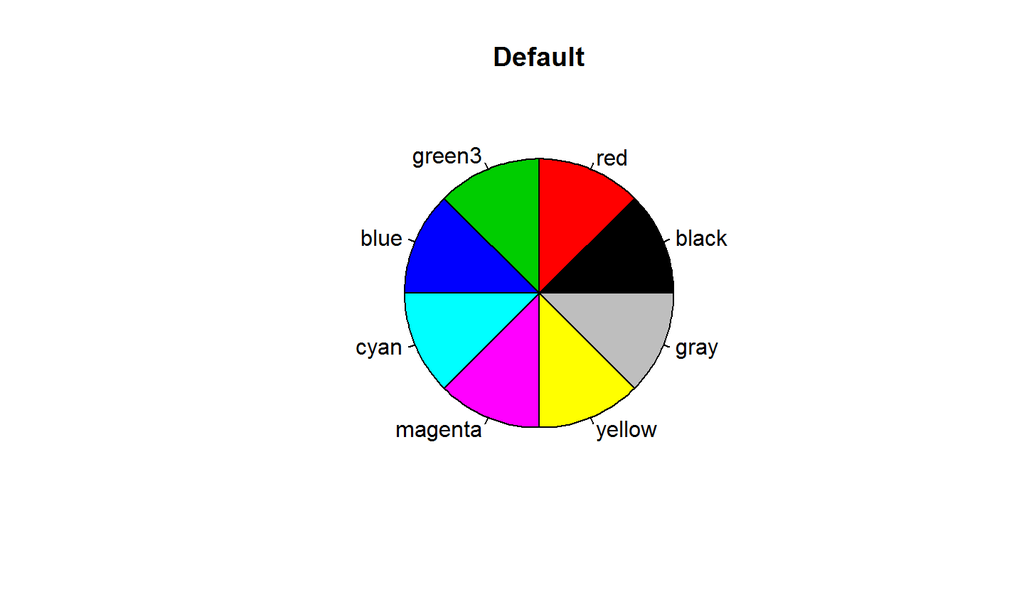

```r
pie(rep(1,length(palette())),col=palette(),
    labels=palette())
title(main="Default")
```

## The rainbow pallette

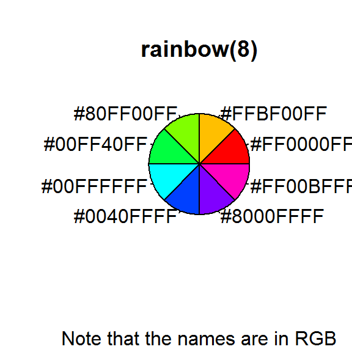

```r
numColors<-8
pie(rep(1,numColors),col=rainbow(numColors),
    labels=rainbow(numColors))
title(main=paste("rainbow(",numColors,")",sep=""))
title(sub="Note that the names are in RGB")
```

## R Color Brewer

An overview of color schemes is at colorbrewer2.org. They're implemented in the RColorBrewer package.

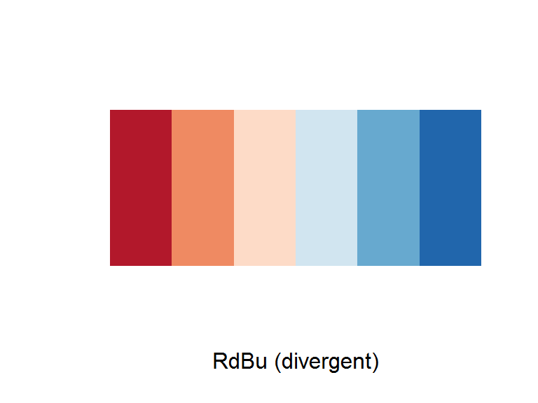

```r
library(RColorBrewer)
display.brewer.pal(6,"RdBu")
```

## Dplyr

## Overview

[Dplyr](http://blog.rstudio.org/2015/09/04/dplyr-0-4-3/) is another RStudio package that is designed specifically to handle the tasks covered in the data frames presentation.

- select - pick columns by name
- filter - keep rows matching criteria
- mutate - add new variables
- arrange - reorder rows
- summarize - reduce variables to values

A major advantage of `dplyr` is the speed at which it handles large data sets.An alternative to `dplyr` is the `data.table` package.

There's also a `dplyr` [cheat sheet](http://www.rstudio.com/wp-content/uploads/2015/02/data-wrangling-cheatsheet.pdf)

We'll only cover the basics as there are a number of additional resources available.

### Hadley Wickham Presentations

- [RStudio Webinar: The Grammar and Graphics of Data Science](https://pages.rstudio.net/Webinar-Series-Recording-Essential-Tools-for-R.html)
- [Hadley Wickham's Dplyr Tutorial](https://www.dropbox.com/sh/i8qnluwmuieicxc/AAAgt9tIKoIm7WZKIyK25lh6a)
- [UseR! 2014 Presentation Part 1](https://www.youtube.com/watch?v=8SGif63VW6E)
- [UseR! 2014 Presentation Part 2](https://www.youtube.com/watch?v=Ue08LVuk790)

### Others

- [Data School's Tutorial](https://www.youtube.com/watch?v=jWjqLW-u3hc&feature=youtu.be)

## NYC Flight Data

The above referenced tutorials and presntations use data from the `nycflights13` package. On-time data for all flights that departed NYC (JFK, LGA, or EWR) in 2013.

```r
library(dplyr)
library(nycflights13)
data(flights)
```

```r
class(flights)
```

```
## [1] "tbl_df"     "tbl"        "data.frame"
```

```r
dim(flights)
```

```
## [1] 336776     16
```

Note that flights is of class `tbl_df`. The main advantage of this class is it only prints what can fit on the screen and `[` doesn't need `drop=FALSE`.

```r
flights
```

```
## Source: local data frame [336,776 x 16]
##
##     year month   day dep_time dep_delay arr_time arr_delay carrier tailnum
##    (int) (int) (int)    (int)     (dbl)    (int)     (dbl)   (chr)   (chr)
## 1   2013     1     1      517         2      830        11      UA  N14228
## 2   2013     1     1      533         4      850        20      UA  N24211
## 3   2013     1     1      542         2      923        33      AA  N619AA
## 4   2013     1     1      544        -1     1004       -18      B6  N804JB
## 5   2013     1     1      554        -6      812       -25      DL  N668DN
## 6   2013     1     1      554        -4      740        12      UA  N39463
## 7   2013     1     1      555        -5      913        19      B6  N516JB
## 8   2013     1     1      557        -3      709       -14      EV  N829AS
## 9   2013     1     1      557        -3      838        -8      B6  N593JB
## 10  2013     1     1      558        -2      753         8      AA  N3ALAA
## ..   ...   ...   ...      ...       ...      ...       ...     ...     ...
## Variables not shown: flight (int), origin (chr), dest (chr), air_time
##   (dbl), distance (dbl), hour (dbl), minute (dbl)
```

## Lahman Database

Since the flights data is used in the other resources, we'll continue using the Lahman baseball database that we used earlier.

```r
library(Lahman)
class(Master)
```

```
## [1] "data.frame"
```

## Filter

Find Babe Ruth in the Master player table. It'll be a subset of a data frame so it's a data frame. We need to convert `Master` to a `tbl_df` (this isn't necessary if you've used `read_csv` in the `readr` package.)

```r
names(Master)
```

```
##  [1] "playerID"     "birthYear"    "birthMonth"   "birthDay"
##  [5] "birthCountry" "birthState"   "birthCity"    "deathYear"
##  [9] "deathMonth"   "deathDay"     "deathCountry" "deathState"
## [13] "deathCity"    "nameFirst"    "nameLast"     "nameGiven"
## [17] "weight"       "height"       "bats"         "throws"
## [21] "debut"        "finalGame"    "retroID"      "bbrefID"
## [25] "deathDate"    "birthDate"
```

```r
Master<-tbl_df(Master)
ruthTable<-filter(Master,nameLast=="Ruth")
```

```r
class(ruthTable)
```

```
## [1] "tbl_df"     "tbl"        "data.frame"
```

```r
ruthTable
```

```
## Source: local data frame [1 x 26]
##
##   playerID birthYear birthMonth birthDay birthCountry birthState birthCity
##      (chr)     (int)      (int)    (int)        (chr)      (chr)     (chr)
## 1 ruthba01      1895          2        6          USA         MD Baltimore
## Variables not shown: deathYear (int), deathMonth (int), deathDay (int),
##   deathCountry (chr), deathState (chr), deathCity (chr), nameFirst (chr),
##   nameLast (chr), nameGiven (chr), weight (int), height (int), bats
##   (fctr), throws (fctr), debut (chr), finalGame (chr), retroID (chr),
##   bbrefID (chr), deathDate (date), birthDate (date)
```

Observations:

- The first argument in `filter` is the data name.
- We used the column name within the function without referring to the data.
- A `tbl_df` object was returned.

Suppose we did the same thing with Ted Williams. There are more than one player with a last name of Williams.

```r
williamsTable<-filter(Master,nameLast=="Williams")
nrow(williamsTable)
```

```
## [1] 76
```

```r
tedWilliams<-filter(williamsTable,nameFirst=="Ted")
tedWilliams
```

```
## Source: local data frame [1 x 26]
##
##    playerID birthYear birthMonth birthDay birthCountry birthState
##       (chr)     (int)      (int)    (int)        (chr)      (chr)
## 1 willite01      1918          8       30          USA         CA
## Variables not shown: birthCity (chr), deathYear (int), deathMonth (int),
##   deathDay (int), deathCountry (chr), deathState (chr), deathCity (chr),
##   nameFirst (chr), nameLast (chr), nameGiven (chr), weight (int), height
##   (int), bats (fctr), throws (fctr), debut (chr), finalGame (chr), retroID
##   (chr), bbrefID (chr), deathDate (date), birthDate (date)
```

Of course, we could have created the table with one command.

```r
tw<-filter(Master,nameFirst=="Ted" & nameLast=="Williams")
tw
```

```
## Source: local data frame [1 x 26]
##
##    playerID birthYear birthMonth birthDay birthCountry birthState
##       (chr)     (int)      (int)    (int)        (chr)      (chr)
## 1 willite01      1918          8       30          USA         CA
## Variables not shown: birthCity (chr), deathYear (int), deathMonth (int),
##   deathDay (int), deathCountry (chr), deathState (chr), deathCity (chr),
##   nameFirst (chr), nameLast (chr), nameGiven (chr), weight (int), height
##   (int), bats (fctr), throws (fctr), debut (chr), finalGame (chr), retroID
##   (chr), bbrefID (chr), deathDate (date), birthDate (date)
```

## Select

Now lets select the `playerID`, `nameLast`, `nameFirst`,`bats`, and `throws`.

```r
select(Master,playerID,nameLast,nameFirst,bats,throws)
```

```
## Source: local data frame [18,589 x 5]
##
##     playerID    nameLast nameFirst   bats throws
##        (chr)       (chr)     (chr) (fctr) (fctr)
## 1  aardsda01     Aardsma     David      R      R
## 2  aaronha01       Aaron      Hank      R      R
## 3  aaronto01       Aaron    Tommie      R      R
## 4   aasedo01        Aase       Don      R      R
## 5   abadan01        Abad      Andy      L      L
## 6   abadfe01        Abad  Fernando      L      L
## 7  abadijo01      Abadie      John      R      R
## 8  abbated01 Abbaticchio        Ed      R      R
## 9  abbeybe01       Abbey      Bert      R      R
## 10 abbeych01       Abbey   Charlie      L      L
## ..       ...         ...       ...    ...    ...
```

## Combine `select` and `filter`

The pipe operator `%>%` allows for a syntax that mirrors your thought process.

- Start with the data frame then (`%>%`)
- Convert it to an object of class `tbl_df` then (`%>%`)
- `select` the columns you want then (`%>%`)
- `filter` by the desired criteria.

```r
Master %>% tbl_df() %>%
      select(playerID,nameLast,nameFirst,bats,throws) %>%
      filter(nameLast=="Williams" & nameFirst=="Ted")
```

```
## Source: local data frame [1 x 5]
##
##    playerID nameLast nameFirst   bats throws
##       (chr)    (chr)     (chr) (fctr) (fctr)
## 1 willite01 Williams       Ted      L      R
```

## Mutate

Use the batting table to calculate a batting average (H/AB). Use only players with at least 600 AB from 2000-2014. (Note that you'll only know the player's ID and not his name.)

```r
tempBatting <- Batting %>% tbl_df %>% filter(yearID > 1999 & AB >599) %>%
  select(playerID,yearID,AB,H) %>% mutate(AVG=round(H/AB,3))
tempBatting
```

```
## Source: local data frame [423 x 5]
##
##     playerID yearID    AB     H   AVG
##        (chr)  (int) (int) (int) (dbl)
## 1  alomaro01   2000   610   189 0.310
## 2  anderga01   2000   647   185 0.286
## 3  batisto01   2000   620   163 0.263
## 4   cruzjo02   2000   603   146 0.242
## 5  damonjo01   2000   655   214 0.327
## 6  durhara01   2000   614   172 0.280
## 7    dyeje01   2000   601   193 0.321
## 8  erstada01   2000   676   240 0.355
## 9  glanvdo01   2000   637   175 0.275
## 10 gonzalu01   2000   618   192 0.311
## ..       ...    ...   ...   ...   ...
```

## Arrange

Add the Player Info and sort in descending order.

```r
inner_join(tempBatting,Master,by="playerID") %>%
  select(nameLast,nameFirst,yearID,AB,H,AVG) %>%
  arrange(desc(AVG))
```

```
## Source: local data frame [423 x 6]
##
##    nameLast nameFirst yearID    AB     H   AVG
##       (chr)     (chr)  (int) (int) (int) (dbl)
## 1    Suzuki    Ichiro   2004   704   262 0.372
## 2    Erstad     Darin   2000   676   240 0.355
## 3    Suzuki    Ichiro   2009   639   225 0.352
## 4    Suzuki    Ichiro   2007   678   238 0.351
## 5    Suzuki    Ichiro   2001   692   242 0.350
## 6     Jeter     Derek   2006   623   214 0.343
## 7    Altuve      Jose   2014   660   225 0.341
## 8  Holliday      Matt   2007   636   216 0.340
## 9  Gonzalez    Adrian   2011   630   213 0.338
## 10    Young   Michael   2011   631   213 0.338
## ..      ...       ...    ...   ...   ...   ...
```

## Summarize

- Pitchers with no games started in the 1960's
- Left-handed.
- Played at least 5 seasons
- Compute strikeouts per 27 outs

```r
Master<-Master %>% tbl_df()
Pitching<-Pitching %>% tbl_df()
temp<-inner_join(Pitching,Master,by="playerID") %>%
 filter(yearID >1959 & yearID <=1969) %>%
  filter(throws=="L" & GS==0) %>%
  select(playerID,nameLast,nameFirst,G,IPouts,SO) %>%
  group_by(playerID,nameLast,nameFirst) %>% summarize(Seasons=n(),Games=sum(G),Outs=sum(IPouts),SO=sum(SO)) %>%
  mutate(SO_27=round((SO/Outs)*27,1)) %>%
  filter(Seasons>=5) %>%
  select(nameLast,nameFirst,Seasons,Games,Outs,SO,SO_27)
```

```r
temp
```

```
## Source: local data frame [15 x 8]
## Groups: playerID, nameLast [15]
##
##     playerID   nameLast nameFirst Seasons Games  Outs    SO SO_27
##        (chr)      (chr)     (chr)   (int) (int) (int) (int) (dbl)
## 1  allenbo04      Allen       Bob       5   204   822   199   6.5
## 2  bridgma01    Bridges  Marshall       6   159   714   199   7.5
## 3  earlear01     Earley    Arnold       5   107   441   109   6.7
## 4  grzenjo01    Grzenda       Joe       5    94   354    64   4.9
## 5  hamilst01   Hamilton     Steve       6   161   711   204   7.7
## 6  henrybi01      Henry      Bill      10   308  1059   285   7.3
## 7  hoeftbi01      Hoeft     Billy       5   124   483   102   5.7
## 8  hoernjo01    Hoerner       Joe       6   214   774   196   6.8
## 9  mackeke01  MacKenzie       Ken       6    87   385    91   6.4
## 10 perraro01 Perranoski       Ron       8   536  2595   527   5.5
## 11 roggega01 Roggenburk     Garry       5    36   155    21   3.7
## 12 shantbo01     Shantz     Bobby       6   175   796   213   7.2
## 13 shortbi01      Short      Bill       5    57   142    30   5.7
## 14 sprinja01     Spring      Jack       6   131   412    54   3.5
## 15 woodeha01 Woodeshick       Hal       6   289  1189   261   5.9
```